# Reproducible Research: Peer Assessment 1

## Loading and preprocessing the data

Load the required libraries

```r
library(dplyr)
library(tidyr)
library(ggplot2)
```

Download and unzip dataset

```r
url<-"https://d396qusza40orc.cloudfront.net/repdata%2Fdata%2Factivity.zip"
destfile<-paste0(getwd(),"/activity_monitoring_data.zip")
download.file(url,destfile)
unzip("activity_monitoring_data.zip")
```

Read the activity dataset csv into R

```r
activity_data <- read.csv(paste0(getwd(),"/activity.csv"))
```

## What is mean total number of steps taken per day?

```r
daily_steps <- activity_data %>%
  group_by(date) %>%
  summarise(total_steps = sum(steps, na.rm = TRUE))

mean_steps <- daily_steps %>%
  summarise(daily_steps = mean(total_steps, na.rm = TRUE))

median_steps <- daily_steps %>%
  summarise(daily_steps = median(total_steps, na.rm = TRUE))
```

The mean of the total number of steps taken per day is 9354.2295082 and the median of the total number of steps taken per day is 10395.

Ignoring NAs, the mean total number of steps taken per day is 9354.2295082.

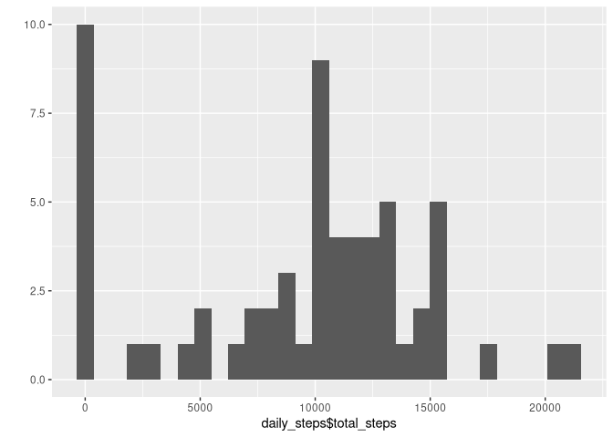

```r
qplot(daily_steps$total_steps, geom="histogram")
```

## What is the average daily activity pattern?

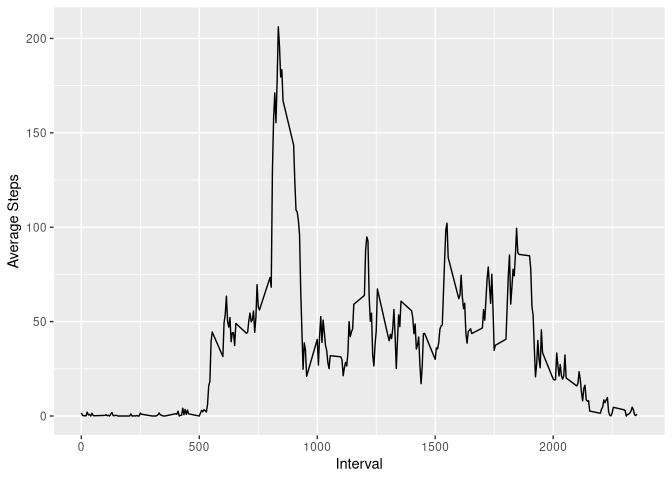

```r
interval_steps <- activity_data %>%
  group_by(interval) %>%
  summarise(average_steps = mean(steps, na.rm = TRUE))

interval_steps <- as.data.frame(interval_steps)

ggplot(interval_steps, aes(interval, average_steps)) + geom_line() +
  xlab("Interval") + ylab("Average Steps")
```

The interval with the maximum average steps across all the days is interval 835.

## Imputing missing values

```r
NAs <- nrow(((activity_data[rowSums(is.na(activity_data)), ])))
```

The total number of rows with NA in the activity dataset is 2304.

The following code fills the missing values in the dataset by replacing NAs with the mean steps observed in the affected interval. Otherwise the dataset is identical.

```r
activity_data <- activity_data %>%
  group_by(interval) %>%
  mutate(steps=ifelse(is.na(steps),mean(steps,na.rm=TRUE),steps)) %>%
  ungroup()
```

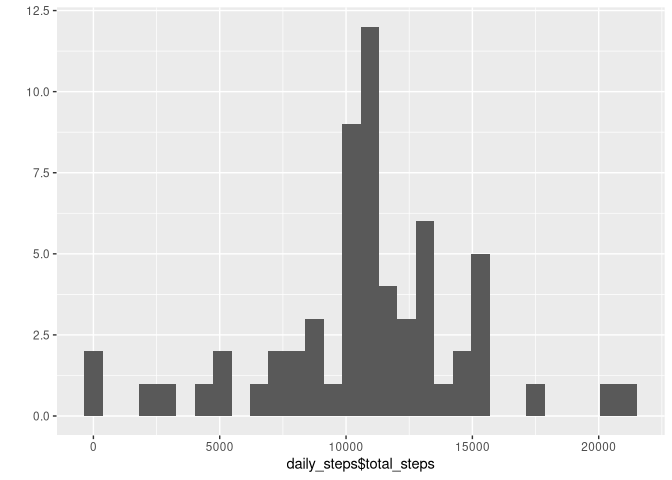

```r
daily_steps <- activity_data %>%
  group_by(date) %>%
  summarise(total_steps = sum(steps, na.rm = FALSE))

mean_steps <- daily_steps %>%
  summarise(daily_steps = mean(total_steps, na.rm = FALSE))

median_steps <- daily_steps %>%
  summarise(daily_steps = median(total_steps, na.rm = FALSE))

qplot(daily_steps$total_steps, geom="histogram")
```

### Are there differences in activity patterns between weekdays and weekends?

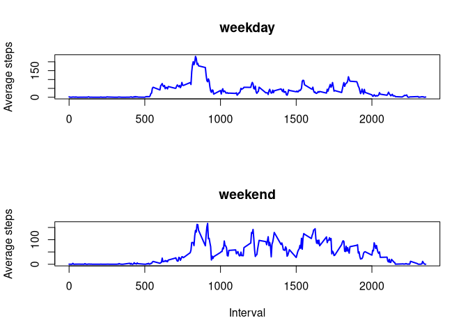

```r
activity_data <- activity_data %>%
  mutate(weekday = weekdays(as.POSIXct(date))) %>%
  mutate(weekday = case_when(weekday %in% c("Saturday", "Sunday") ~ "weekend",
                             weekday %in% c("Monday", "Tuesday", "Wednesday", "Thursday", "Friday")  ~ "weekday")) %>%
  mutate(weekday = as.factor(weekday))

weekday_steps <- activity_data %>%
  filter(weekday == "weekday") %>%
  group_by(interval) %>%
  summarise(average_steps = mean(steps))

weekend_steps <- activity_data %>%
  filter(weekday == "weekend") %>%
  group_by(interval) %>%
  summarise(average_steps = mean(steps))

layout(matrix(c(1,2), nrow = 2, ncol = 1, byrow = TRUE))
plot(weekday_steps$interval, weekday_steps$average_steps, type='l', xlab = '', ylab= "Average steps", col="blue", lwd=2 ,main="weekday")
plot(weekend_steps$interval, weekend_steps$average_steps, type='l', xlab = "Interval", ylab= "Average steps", col="blue", lwd=2,main="weekend")
```

Plotting weekday and weekend activity data seperately shows that activity is distributed more evenly throughout the day on weekends unlike the weekday that sees a clear peak around 8-9 AM. Activity appears to be overall higher on weekends than on weekdays, making for a pronounced difference in activity patterns between weekdays and weekends.